# R Notebook

The GME short squeeze of January 2021 is one of the most poignant cases of short squeezing due to the organisation of it through non-institutional investors (Vasileiou et al., 2021). There has been a large volume of work investigating the trends and actions of the assets subject to the short squeeze, but little has been investigated to analyse the long-term effects of herding on the assets targeted. The effect of the GME short squeeze have been shown to have changed the perception of the retail investor’s market speculation and thus behaviour (Klein, 2021). The long-lasting effects of investor behaviour for stocks after the initial period of mass action and hysteria could prove useful for informing investments following a period of similar circumstances. In this assignment, the stock prices of the targeted stocks of the short squeeze are analysed for potential herding behaviour for the period of the squeeze itself, January 2021, through to January 2023. An intuitive assumption is that the key influence on the stock prices was due to herding behaviour. The targeting of “meme stocks” for retail investors was due to information shared communally through social media platforms such as reddit’s r/wallstreetbets forum. This is best reflected in the tagline for the movement: “Apes together Strong”, typifying the large number of individual investors influenced by social and informational cues who then acted on these in a coordinated manner.

The list of assets selected for this analysis are made up of most heavily shorted securities that experienced significant price increases for the same time period.

1. Gamestop (GME) – Gamestop is an American video game, consumer electronics, and gaming merchandise retailer. Gamestop was the most prominent stock during the short squeeze. The focus and targeting of this stock was due to the heavy shorting of Gamestop by the investment fund Melvin Capital. Notorious retail investor Keith Gill turned a $53,000 investment into ~$50M by targeting Gamestop.
2. AMC Entertainment Holdings (AMC) – AMC is a movie theatre chain that was also the target of the January 2021 short squeeze.
3. AMC Networks (AMCX) – AMC networks. This was targeted by accident by members of r/wallstreetbets thinking they were targeting AMC. As a result, AMCX received a significant financial boost.
4. American Airlines Group (AAL) – AAL is an American airline group which boasts the largest fleet size in the world. AAL was mentioned in the r/wallstreetbets forum and experienced a significant price change due to the investor behaviour that followed.
5. Bed, Bath and Beyond (BBBL) – Bed, Bath and Beyond is an American big-box store company. It was also declared a “meme stock” and has been the target of the January 2021 short squeeze. Interestingly, there is speculation that it may again be the target of a short squeeze as of April 2023 (Noonan, 2023).
6. BlackBerry (BB) – Blackberry is a software company that previously had significant market share in Telecommunications and Electronics but has shifted to a focus in Cybersecurity. BB has also received recent speculation on a further short squeeze (Schaffer, 2023).
7. Genius Brands International (GNUS) – Genius Brands International is an entertainment company that was targeted in January 2021 as a heavily shorted stock. It has also been recently speculated as a target for potential short squeeze (Business Insider, 2023).
8. Nokia (NOK) – Nokia is a multinational telecommunications and technology company that has been the target of speculation for short squeezing (Benzinga Insights, 2023).
9. Express Inc. (EXPR) – Express is an American fashion retailer that targets trendy young clientele.
10. iRobot (IRBT) – iRobot is an American robotics company, that was heavily targeted during the January 2021 short squeeze and saw soaring stock prices (The Street, 2021).

First the necessary libraries for analysis are loaded

```r
library(xts)
library(zoo)
library(BatchGetSymbols)
library(yahoofinancer)
library(TTR)
library(quantmod)
library(MSwM)
library(brms)
library(quantreg)
library(tvReg)
library(rstanarm)
library(PerformanceAnalytics)
library(pastecs)
library(lmtest)
library(ggplot2)
library(sandwich)
```

The selected stocks price information is taken from the yahoo finance resource and combined to have the combined closing prices in an object.

The plot of the close prices of these stocks shows a high increase in January reflecting the period of the short squeeze.

Since then there has a been a slow decreasing trend with some uptick around August 2022.

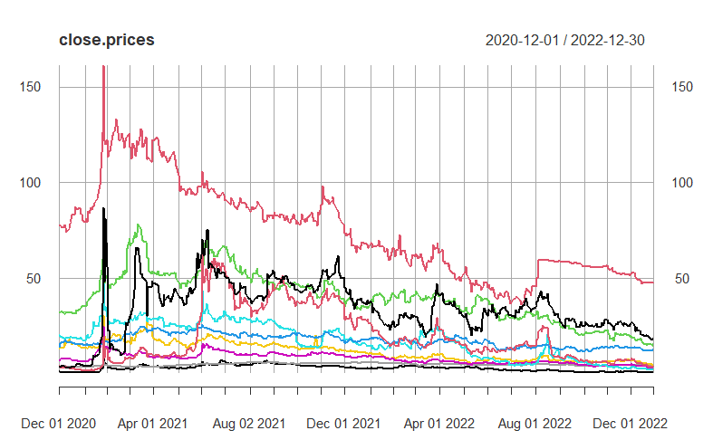

Next the returns and the log of the returns of the closing prices is calculated. The descriptive statistics are then inspected for the following metrics:

1. Return - The average return and the total return can be seen from the sum and mean rows of data. Notably all of these stocks except for Gamestop and Nokia have had an overall decline in price as reflected in the sum row. Bed, Bath and Beyond was the worst performing stock with the lowest overall return, whereas Gamestop was overall the best performing stock.
2. Volatility - The volatility of each stock is reflected in the standard deviation of returns. As can be seen from the descriptive statistics table, all of the stocks have comparatively high volatility, indicating the presence of outliers in returns. This is to be expected as the stocks have been the subject of a short squeeze which inherently causes extreme price fluctuations and thus high volatility of returns.

|  | GME.Close | AMC.Close | AMCX.Close | AAL.Close | BBBY.Close | BB.Close | GNUS.Close | NOK.Close | EXPR.Close | IRBT.Close |
| --- | --- | --- | --- | --- | --- | --- | --- | --- | --- | --- |
| nbr.val | 524.000000000 | 5.240000e+02 | 524.000000000 | 5.240000e+02 | 524.000000000 | 524.000000000 | 524.000000000 | 5.240000e+02 | 5.240000e+02 | 5.240000e+02 |
| nbr.null | 2.000000000 | 4.000000e+00 | 3.000000000 | 3.000000e+00 | 4.000000000 | 9.000000000 | 20.000000000 | 2.600000e+01 | 1.800000e+01 | 2.000000e+00 |
| nbr.na | 0.000000000 | 0.000000e+00 | 0.000000000 | 0.000000e+00 | 0.000000000 | 0.000000000 | 0.000000000 | 0.000000e+00 | 0.000000e+00 | 0.000000e+00 |
| min | -0.916290732 | -8.354752e-01 | -0.214696979 | -1.277711e-01 | -0.519850939 | -0.538427552 | -0.440381347 | -3.340325e-01 | -7.089787e-01 | -2.783766e-01 |
| max | 0.853716369 | 1.389314e+00 | 0.211811398 | 1.009727e-01 | 0.483078053 | 0.282648294 | 0.593686422 | 3.255399e-01 | 1.144684e+00 | 2.429462e-01 |
| range | 1.770007101 | 2.224789e+00 | 0.426508377 | 2.287438e-01 | 1.002928992 | 0.821075846 | 1.034067769 | 6.595724e-01 | 1.853662e+00 | 5.213228e-01 |
| sum | 1.541890588 | -1.946532e-02 | -0.725175050 | -1.149839e-01 | -2.094271237 | -0.764182957 | -1.050896809 | 1.335314e-01 | -4.989912e-01 | -4.746934e-01 |
| median | -0.002244098 | -6.859935e-03 | -0.001624824 | -1.362026e-03 | -0.006549740 | -0.003574661 | -0.006949312 | 0.000000e+00 | -8.122291e-03 | -1.671828e-03 |
| mean | 0.002942539 | -3.714755e-05 | -0.001383922 | -2.194349e-04 | -0.003996701 | -0.001458364 | -0.002005528 | 2.548309e-04 | -9.522732e-04 | -9.059035e-04 |
| SE.mean | 0.004888546 | 4.951309e-03 | 0.001686368 | 1.426748e-03 | 0.003408258 | 0.002294150 | 0.002592337 | 1.336253e-03 | 4.546692e-03 | 1.515523e-03 |

[output cut: 4 more lines]

A key metric to measure to analyse whether herding is present in a market is the Cross-Sectional Absolute Deviation of returns (CSAD). By measuring the relationship between CSAD and the market return, behaviour suggestive of herding can be inferred if the relationship between them is non-linear. If herding is not present then the relationship between CSAD and market return should be both positive and linear.

```r
## function for calculating CSAD, Rm and Rm^2
exchange.herd = function(return)
{
  n=ncol(return)
  Rm = rowMeans(return)
  temp_dif =abs(return-Rm)
  temp_sum = rowSums(temp_dif)
  CSAD = temp_sum / ncol(return)
  CSAD = cbind (CSAD, Rm)
  return (CSAD)
}

## CSAD is the cross sectional absolute deviation
## Rm is the average absolute market return

f <- exchange.herd(return)

CSAD.df = fortify.zoo(f) # converting f into a dataframe (to simplify further calculations)
CSAD.df$Rm2 = CSAD.df$Rm^2 # calculating Rm^2
CSAD.df = CSAD.df[-c(1),]
```

The first linear model indicates that there is a significant positive linear relationship between CSAD and market return. This can be seen for the high coefficent for x1 with a very statistical significance showing a strong positive linear relationship. Though the coefficient for x2 is suitably negative, it is not statistically significant. This indicates that herding is not present in this market overall for this time period.

```r
## specify input names for ease of interpretation in the regression model
y = CSAD.df$CSAD
x1 = abs(CSAD.df$Rm)
x2 = CSAD.df$Rm2

## Linear model
lm1 <- lm(y~x1+x2)
print(lm1)
```

```
Call:
lm(formula = y ~ x1 + x2)

Coefficients:
(Intercept)           x1           x2
   0.223243     0.929035    -0.003616
```

```r
summary(lm1)
```

```
Call:
lm(formula = y ~ x1 + x2)

Residuals:
     Min       1Q   Median       3Q      Max
-0.85833 -0.21012 -0.06324  0.11915  2.46980

Coefficients:
             Estimate Std. Error t value Pr(>|t|)
(Intercept)  0.223243   0.023129   9.652   <2e-16 ***
x1           0.929035   0.032309  28.755   <2e-16 ***
x2          -0.003616   0.002930  -1.234    0.218
---
Signif. codes:  0 ‘***’ 0.001 ‘**’ 0.01 ‘*’ 0.05 ‘.’ 0.1 ‘ ’ 1

Residual standard error: 0.3606 on 520 degrees of freedom
Multiple R-squared:  0.8716,    Adjusted R-squared:  0.8711
F-statistic:  1765 on 2 and 520 DF,  p-value: < 2.2e-16
```

Checking next for change in market return on up/down market days. First a binary column is constructed to indicate whether the market return increases (1) or decreases (0). Then a regression model is fitted with separate input for up and down days using the binary input as an additional parameter.

Again from this model there is a strong positive linear relationship between CSAD and market return for both up and down days for market return. This can be seen from the positive z1 and z2 coefficients, with statistical significance. This again indicates that herding is not present in this market over the period measured.

The conclusion drawn from these two models is that despite a strong herding behaviour that has been the topic of much discussion in January 2021, this behaviour did not persist through to later periods and these specific stocks did adhere to typical market behaviour.

Also to note are the adjusted R square for both models having high values of 0.8711 and 0.8738 respectively. This indicates that ~87% of the variance of CSAD is captured from these models.

```r
## adapting the regression model for up and down days

## first thing to do is make a new binary column D_up for if the Rm went up or down
D_up <- matrix(nrow=length(CSAD.df$Rm))

for (i in 1:nrow(CSAD.df))
{
  if (CSAD.df$Rm[i] >= 0) {
    D_up[i,] = 1
  }
  else if (CSAD.df$Rm[i] <= 0) {
    D_up[i,] = 0
  }}

## binding D_up to the CSAD data
CSAD.df <- cbind(CSAD.df, D_up)

## naming the parameters as z to differentiate from the previous x parameters
y = CSAD.df$CSAD
z1 <- CSAD.df$D_up*abs(CSAD.df$Rm)
z2 <- (1-CSAD.df$D_up)*abs(CSAD.df$Rm)
z3 <- CSAD.df$D_up*CSAD.df$Rm2
z4 <- (1-CSAD.df$D_up)*CSAD.df$Rm2

## building lm model with up and down days included
lm2 <- lm(y ~ z1 + z2 + z3 + z4)
print(lm2)
summary(lm2)
```

[output not shown]

Following this, a model is made to check for herding on high and low volatility days. The selected criteria for when volatility is either high or low is based off of the returns being higher or lower than 1 standard deviation from the mean. This criteria is checked for all values of Rm and stored in the object D_vol. This is then bound to the CSAD data frame and called upon when defining the inputs for the regression model.

The results from this model are not as conclusive as for the previous two models. Though there is a significant positive linear relationship between market returns and CSAD on days of high volatility, the negative coefficient for Rm^2 for high volatility is negative but not highly significant. Leading to an inconclusive result for the presence of herding on high volatility days.

The results for low volatility days are even less interpretable. There is significance for a linear relationship between market returns and CSAD for low volatility days but there is no significant relationship present for Rm^2 for low volatility days. This does indicate that no herding is present but is not entirely conclusive.

```r
## trying now to quantify high and low volatility days
## taking 1 standard deviation of the mean of Rm to mean high/low volatility

D_vol <- matrix(nrow=length(CSAD.df$Rm))

for (i in 1:nrow(CSAD.df))
{
  if (abs(CSAD.df$Rm[i]) >= (stat.desc(CSAD.df)[13,3]+stat.desc(CSAD.df)[9,3])) {
    D_vol[i,] = 1
  }
  else if (abs(CSAD.df$Rm[i]) <= (stat.desc(CSAD.df)[13,3]+stat.desc(CSAD.df)[9,3])) {
    D_vol[i,] = 0
  }
}
CSAD.df <- cbind(CSAD.df, D_vol)

y = CSAD.df$CSAD
v1 <- CSAD.df$D_vol*abs(CSAD.df$Rm)
v2 <- (1-CSAD.df$D_vol)*abs(CSAD.df$Rm)
v3 <- CSAD.df$D_vol*CSAD.df$Rm2
v4 <- (1-CSAD.df$D_vol)*CSAD.df$Rm2

## building lm model with high and low volatility included
lm3 <- lm(y ~ v1 + v2 + v3 + v4)
summary(lm3)
```

```
Call:
lm(formula = y ~ v1 + v2 + v3 + v4)

Residuals:
     Min       1Q   Median       3Q      Max
-0.79108 -0.20399 -0.06387  0.12726  2.46084

Coefficients:
             Estimate Std. Error t value Pr(>|t|)
(Intercept)  0.346854   0.038822   8.934   <2e-16 ***
v1           0.942890   0.035046  26.904   <2e-16 ***
v2           0.448093   0.175000   2.561   0.0107 *
v3          -0.005782   0.003076  -1.880   0.0607 .
v4           0.243101   0.158081   1.538   0.1247
---
Signif. codes:  0 ‘***’ 0.001 ‘**’ 0.01 ‘*’ 0.05 ‘.’ 0.1 ‘ ’ 1

Residual standard error: 0.3519 on 518 degrees of freedom
Multiple R-squared:  0.8782,    Adjusted R-squared:  0.8772
F-statistic: 933.5 on 4 and 518 DF,  p-value: < 2.2e-16
```

As this is a Regression, multiple methods may be tried to examine the behaviour of the stocks more comprehensively.

Next, the Newey-West Heteroscedasticity and Autocorrelation consistent (HAC) estimators are used to further improve the efficiency of the estimates by accounting for heteroscedasticity and autocorrelation.

Though this model may be better informed, the results remain the same and indicate that herding is not present in this market.

```r
## Newey-West Heteroscedasticity and Autocorrelation consistent (HAC) estimators

## coefficient test
coeftest(lm1,vcov=NeweyWest(lm1,verbose=T))
```

```
Lag truncation parameter chosen: 26

t test of coefficients:

              Estimate Std. Error t value  Pr(>|t|)
(Intercept)  0.2232427  0.0470537  4.7444 2.705e-06 ***
x1           0.9290354  0.0895686 10.3723 < 2.2e-16 ***
x2          -0.0036164  0.0073599 -0.4914    0.6234
---
Signif. codes:  0 ‘***’ 0.001 ‘**’ 0.01 ‘*’ 0.05 ‘.’ 0.1 ‘ ’ 1
```

```r
## and again for the up and down days model
coeftest(lm2,vcov=NeweyWest(lm2,verbose=T))
```

```
Lag truncation parameter chosen: 10

t test of coefficients:

              Estimate Std. Error t value  Pr(>|t|)
(Intercept)  0.2280494  0.0423946  5.3792 1.135e-07 ***
z1           0.9623279  0.0894276 10.7610 < 2.2e-16 ***
z2           0.8794192  0.0933324  9.4224 < 2.2e-16 ***
z3          -0.0023758  0.0068639 -0.3461    0.7294
z4          -0.0036467  0.0076220 -0.4784    0.6325
---
Signif. codes:  0 ‘***’ 0.001 ‘**’ 0.01 ‘*’ 0.05 ‘.’ 0.1 ‘ ’ 1
```

As there are 2 intuitive period of behaviour for these stocks: the short squeeze time period and thereafter, a markov switching regime may be implemented in the hopes of capturing the difference in behaviour for these time periods.

The results from the first model do show a statistical difference in behaviour for the two different regimes. The second regime conforms to what has been shown from the modelling thus far, an indication that herding is not present in the market.

It is important to now note that the short squeeze of these stocks took place over a short period of time with intra-day price changes having a much richer layer of information to inform the subtleties of herding behaviour during the period of these stocks being short squeezed. Perhaps a deeper analysis at hourly price level could further expand on these results. However, such a data source is available from the Bloomberg finance API for $70 but will not be explored as this is not readily available for a poor university student.

```r
## markov switching model for 2 regimes, based off short squeezing period and thereafter
ms1 = msmFit(lm1, k = 2, sw = rep(TRUE, 4))
summary(ms1)
```

```
Markov Switching Model

Call: msmFit(object = lm1, k = 2, sw = rep(TRUE, 4))
```

|  | AIC | BIC | logLik |
| --- | --- | --- | --- |
|  | 72.07873 | 135.1937 | -30.03937 |

```
Coefficients:

Regime 1
---------
               Estimate Std. Error t value  Pr(>|t|)
(Intercept)(S)   0.4627     0.0606  7.6353 2.243e-14 ***
x1(S)            0.9459     0.0577 16.3934 < 2.2e-16 ***
x2(S)           -0.0068     0.0048 -1.4167    0.1566
---
Signif. codes:  0 ‘***’ 0.001 ‘**’ 0.01 ‘*’ 0.05 ‘.’ 0.1 ‘ ’ 1

Residual standard error: 0.4775943
Multiple R-squared: 0.902

Standardized Residuals:
        Min          Q1         Med          Q3         Max
-0.87968347 -0.11443609 -0.04064577 -0.02319356  2.22479230

Regime 2
---------
               Estimate Std. Error t value  Pr(>|t|)
(Intercept)(S)   0.2588     0.0172 15.0465 < 2.2e-16 ***
x1(S)            0.5019     0.0482 10.4129 < 2.2e-16 ***
x2(S)            0.1005     0.0232  4.3319 1.478e-05 ***
---
Signif. codes:  0 ‘***’ 0.001 ‘**’ 0.01 ‘*’ 0.05 ‘.’ 0.1 ‘ ’ 1

Residual standard error: 0.1445661
Multiple R-squared:  0.79

Standardized Residuals:
        Min          Q1         Med          Q3         Max
-0.31905989 -0.07301085  0.01181283  0.08501266  0.32765261

Transition probabilities:
          Regime 1   Regime 2
Regime 1 0.8539284 0.07451381
Regime 2 0.1460716 0.92548619
```

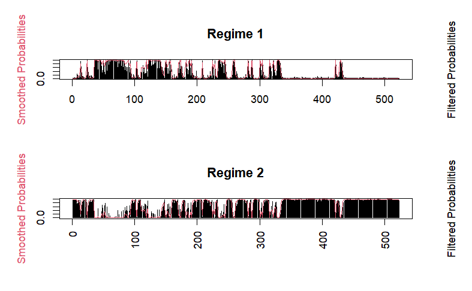

```r
plotProb(ms1 ,which=1)
```

Following from the result of the first Markov-Switching model, a model including the difference for up and down days is investigated to see if there is some underlying cause in the change in return on herding for regime 1.

This model produces the results slightly different to the first model. Though the coefficients for market returns for both up and down days remain to be significantly positively correlated to CSAD, the coefficents for Rm^2 for both high and low days are now significantly linearly correlated with CSAD but with only a weak positive correlation. This does again indicate a lack of herding being present for both up and down days of market returns.

```r
## and again for up/down days aswell
ms2 = msmFit(lm2, k = 2, sw = rep(TRUE, 6))
summary(ms2)
```

```
Markov Switching Model

Call: msmFit(object = lm2, k = 2, sw = rep(TRUE, 6))
```

|  | AIC | BIC | logLik |
| --- | --- | --- | --- |
|  | 74.4378 | 179.6294 | -27.2189 |

```
Coefficients:

Regime 1
---------
               Estimate Std. Error t value  Pr(>|t|)
(Intercept)(S)   0.4550     0.0565  8.0531 8.882e-16 ***
z1(S)            0.9789     0.0732 13.3730 < 2.2e-16 ***
z2(S)            0.8932     0.0678 13.1740 < 2.2e-16 ***
z3(S)           -0.0053     0.0065 -0.8154    0.4148
z4(S)           -0.0064     0.0060 -1.0667    0.2861
---
Signif. codes:  0 ‘***’ 0.001 ‘**’ 0.01 ‘*’ 0.05 ‘.’ 0.1 ‘ ’ 1

Residual standard error: 0.4676497
Multiple R-squared: 0.8965

Standardized Residuals:
        Min          Q1         Med          Q3         Max
-0.82913815 -0.10762272 -0.03641283 -0.02019996  2.34566140

Regime 2
---------
               Estimate Std. Error t value  Pr(>|t|)
(Intercept)(S)   0.2303     0.0144 15.9931 < 2.2e-16 ***
z1(S)            0.6876     0.0302 22.7682 < 2.2e-16 ***
z2(S)            0.5720     0.0331 17.2810 < 2.2e-16 ***
z3(S)            0.0182     0.0039  4.6667 3.061e-06 ***
z4(S)            0.0183     0.0035  5.2286 1.708e-07 ***
---
Signif. codes:  0 ‘***’ 0.001 ‘**’ 0.01 ‘*’ 0.05 ‘.’ 0.1 ‘ ’ 1

Residual standard error: 0.1428423
Multiple R-squared: 0.8936

Standardized Residuals:
         Min           Q1          Med           Q3          Max
-0.378171066 -0.073719178  0.009405437  0.076738962  0.327922313

Transition probabilities:
          Regime 1   Regime 2
Regime 1 0.8708924 0.06974894
Regime 2 0.1291076 0.93025106
```

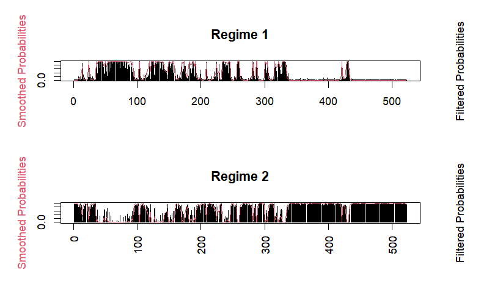

```r
plotProb(ms2 ,which=1)
```

Quantile regression is used as it is far more robust with dealing with extreme skewness and outliers, which can be expected in this particular case.

The results of this are consistent for tau = 0.1 to 0.8, which are reflective of the positive linear relationship between CSAD and market returns. But interestingly for tau = 0.9 the coefficient for x2 changes to be negative. This may indicate inconclusive evidence for no herding at these values.

```r
## quantile regression
taus<-seq(from = .1, to = .9, by = .1)

## quantile regression for the linear model
coef1 <- rq( y ~ x1+x2, tau=taus)
summary (coef1)
```

[output not shown]

This is tested again for up and down days.

This result is the same but shifts the consistency of result from 0.8 to 0.6, showing now that no herding is not conclusive for values in the 0.7-0.9 range for both up and down days of market returns.

```r
summary (coef1)
```

[output not shown]

[output cut: 52 more lines]

[output not shown]

Next a time-varying linear model is done to examine the potential change in coefficients over time. The results from this are expected to see some indication of herding early on in the sample, with the results thus far indicating no herding thereafter.

From the plot of the time varying linear models coefficients, an early trend of negative b2 but also has the presence of a positive x1 coefficient, which does not provide conclusive evidence of herding during this time period. Again this may be due to the lack of detailed hourly data upon which much of the change in returns from the short squeeze took place. Further to this the x1 coefficient remained mostly positive throughout with a small negative dip midway through this period. The x2 coefficient stays positive after the initial period with a large spike midway through the time period.

```r
## time varying linear model
tvlm.fit1 = tvLM(y~x1+x2, bw = NULL  )
```

```
Calculating regression bandwidth... bw =  0.2322003
```

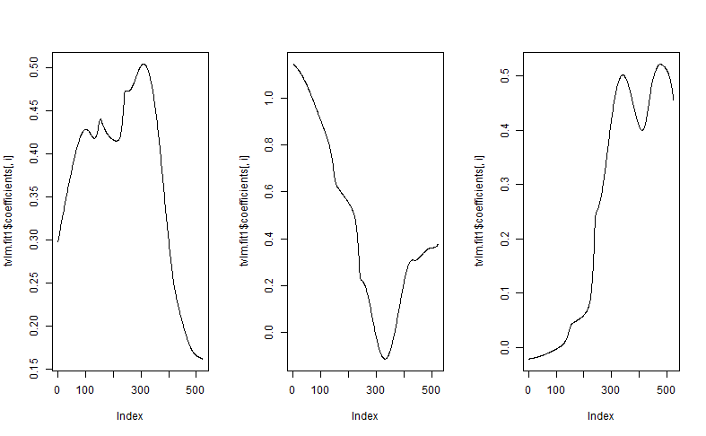

```r
par(mfrow=c(1,3))
for (i in 1:3){
plot(tvlm.fit1$coefficients[,i], type="l")
}
```

This is again repeated for up and down days regression model.

This plot shows very similar behaviour for both up and down days, giving further credence to the presence of herding not being changed by whether the return increase or decrease.

```r
## time varying linear model
tvlm.fit2 = tvLM(y~z1+z2+z3+z4, bw = NULL  )
```

```
Calculating regression bandwidth... bw =  0.3985382
```

```r
head(tvlm.fit2$coefficients)
```

```
     (Intercept)       z1       z2           z3          z4
[1,]   0.3524347 1.049103 1.058609 -0.009980546 -0.01888591
[2,]   0.3530341 1.047862 1.057121 -0.009892067 -0.01877310
[3,]   0.3536243 1.046622 1.055635 -0.009803598 -0.01866042
[4,]   0.3542054 1.045383 1.054152 -0.009715153 -0.01854787
[5,]   0.3547772 1.044147 1.052673 -0.009626746 -0.01843547
[6,]   0.3553396 1.042912 1.051196 -0.009538387 -0.01832321
```

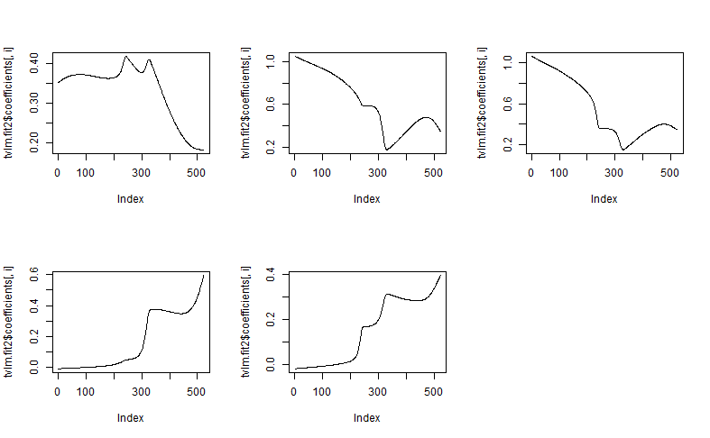

```r
par(mfrow=c(2,3))
for (i in 1:5) {
plot(tvlm.fit2$coefficients[,i], type="l")
}
```

Next, A Bayesian generalised linear model is executed

```r
bayesian_df1 <- data.frame(y, x1, x2)
model.b1 <- stan_glm(y ~ x1 + x2 , data = bayesian_df1, seed = 123)
```

The first model provides results consistent with previous models; an coefficient for market returns of 0.9 with low coefficient for x2. Again giving claim to no herding being present in the market.

```r
summary(model.b1)
```

```
Model Info:
 function:     stan_glm
 family:       gaussian [identity]
 formula:      y ~ x1 + x2
 algorithm:    sampling
 sample:       4000 (posterior sample size)
 priors:       see help('prior_summary')
 observations: 523
 predictors:   3

Estimates:
              mean   sd   10%   50%   90%
(Intercept) 0.2    0.0  0.2   0.2   0.3
x1          0.9    0.0  0.9   0.9   1.0
x2          0.0    0.0  0.0   0.0   0.0
sigma       0.4    0.0  0.3   0.4   0.4

Fit Diagnostics:
           mean   sd   10%   50%   90%
mean_PPD 0.8    0.0  0.8   0.8   0.8

The mean_ppd is the sample average posterior predictive distribution of the outcome variable (for details see help('summary.stanreg')).

MCMC diagnostics
              mcse Rhat n_eff
(Intercept)   0.0  1.0  2415
x1            0.0  1.0  1931
x2            0.0  1.0  1937
sigma         0.0  1.0  2878
mean_PPD      0.0  1.0  3213
log-posterior 0.0  1.0  1386

For each parameter, mcse is Monte Carlo standard error, n_eff is a crude measure of effective sample size, and Rhat is the potential scale reduction factor on split chains (at convergence Rhat=1).
```

Again the model is repeated to account for up and down days.

The results from this model reflect the results from the previous model; positive coefficient for days with both up and down returns with 0 coefficient for the rm^2 input variables. This again gives cause to no herding being present in the market.

```r
bayesian_df2 <- data.frame(y, z1, z2, z3, z4)
model.b2 <- stan_glm(y ~ z1 + z2 + z3 + z4, data = bayesian_df2, seed = 123)
summary(model.b2)
```

```
Model Info:
 function:     stan_glm
 family:       gaussian [identity]
 formula:      y ~ z1 + z2 + z3 + z4
 algorithm:    sampling
 sample:       4000 (posterior sample size)
 priors:       see help('prior_summary')
 observations: 523
 predictors:   5

Estimates:
              mean   sd   10%   50%   90%
(Intercept) 0.2    0.0  0.2   0.2   0.3
z1          1.0    0.0  0.9   1.0   1.0
z2          0.9    0.0  0.8   0.9   0.9
z3          0.0    0.0  0.0   0.0   0.0
z4          0.0    0.0  0.0   0.0   0.0
sigma       0.4    0.0  0.3   0.4   0.4

Fit Diagnostics:
           mean   sd   10%   50%   90%
mean_PPD 0.8    0.0  0.8   0.8   0.8

The mean_ppd is the sample average posterior predictive distribution of the outcome variable (for details see help('summary.stanreg')).

MCMC diagnostics
              mcse Rhat n_eff
(Intercept)   0.0  1.0  2860
z1            0.0  1.0  2106
z2            0.0  1.0  2614
z3            0.0  1.0  2267
z4            0.0  1.0  2759
sigma         0.0  1.0  3649
mean_PPD      0.0  1.0  3804
log-posterior 0.0  1.0  1647

For each parameter, mcse is Monte Carlo standard error, n_eff is a crude measure of effective sample size, and Rhat is the potential scale reduction factor on split chains (at convergence Rhat=1).
```